# Lab_6

### 6η Εργαστηριακή Άσκηση

#### Όνομα: Αλεξανδρόπουλος Σταματης

#### Αριθμός Μητρώου: 03117060

#### Παραδοτεό 1

##### Ερώτημα α

Γράψτε μια ρουτίνα που θα τυπώνει για διαστάσεις $d=2,3,...$ τον εκτιμόμενο με Monte Carlo όγκο της μοναδιαίας μπάλας σε $d$ διαστάσεις, την πραγματική τιμή του και το σχετικό σφάλμα της εκτίμησης. Η ρουτίνα σας θα πρέπει να επιλέγει $N=10^6$ σημεία στον αντίστοιχο κύβο κάθε διάστασης και θα πρέπει να φτάνει μέχρι εκείνη την τιμή της διάστασης που κανένα από τα $N$ επιλεγμένα σημεία δεν έπεσε στη μπάλα.

*Λύση*

Ο κώδικας της άσκησης για d =2 ,...,20 είναι ο εξής:

```python
from numpy import random
from math import gamma, pi

list1 = []
list2 = []

N = 10 ** 6
for d in range( 2,21):
    nhits = 0
    for i in range(N):
        x = random.uniform(-1,1,d)
        if sum(x ** 2) < 1:
            nhits += 1
    vol= 2 ** d * nhits / N
    x = d/2
    vol_real= pi ** x / gamma(x + 1)
    list1.append(vol)
    list2.append(vol_real)

    print ("The Monte Carlo estimate of ω(", d,") is:\t%.5f " % vol )
    print("The actual value of ω(", d,") is:\t\t%.5f " % vol_real)
    print ("Relative error in ", d, " dimensions is:\t%.5f \n" %(abs(vol - vol_real)/vol_real))
```

```
The Monte Carlo estimate of ω( 2 ) is:	3.14112
The actual value of ω( 2 ) is:		3.14159
Relative error in  2  dimensions is:	0.00015

The Monte Carlo estimate of ω( 3 ) is:	4.18621
The actual value of ω( 3 ) is:		4.18879
Relative error in  3  dimensions is:	0.00062

The Monte Carlo estimate of ω( 4 ) is:	4.93166
The actual value of ω( 4 ) is:		4.93480
Relative error in  4  dimensions is:	0.00064

The Monte Carlo estimate of ω( 5 ) is:	5.27258
The actual value of ω( 5 ) is:		5.26379
Relative error in  5  dimensions is:	0.00167

The Monte Carlo estimate of ω( 6 ) is:	5.16038
The actual value of ω( 6 ) is:		5.16771
Relative error in  6  dimensions is:	0.00142

The Monte Carlo estimate of ω( 7 ) is:	4.71757
The actual value of ω( 7 ) is:		4.72477
Relative error in  7  dimensions is:	0.00152

The Monte Carlo estimate of ω( 8 ) is:	4.11546
The actual value of ω( 8 ) is:		4.05871
Relative error in  8  dimensions is:	0.01398

The Monte Carlo estimate of ω( 9 ) is:	3.25734
The actual value of ω( 9 ) is:		3.29851
Relative error in  9  dimensions is:	0.01248

The Monte Carlo estimate of ω( 10 ) is:	2.63680
The actual value of ω( 10 ) is:		2.55016
Relative error in  10  dimensions is:	0.03397

The Monte Carlo estimate of ω( 11 ) is:	1.84525
The actual value of ω( 11 ) is:		1.88410
Relative error in  11  dimensions is:	0.02062

```

[output cut: 20 more lines]

```
The Monte Carlo estimate of ω( 17 ) is:	0.13107
The actual value of ω( 17 ) is:		0.14098
Relative error in  17  dimensions is:	0.07029

The Monte Carlo estimate of ω( 18 ) is:	0.26214
The actual value of ω( 18 ) is:		0.08215
Relative error in  18  dimensions is:	2.19120

The Monte Carlo estimate of ω( 19 ) is:	0.00000
The actual value of ω( 19 ) is:		0.04662
Relative error in  19  dimensions is:	1.00000

The Monte Carlo estimate of ω( 20 ) is:	0.00000
The actual value of ω( 20 ) is:		0.02581
Relative error in  20  dimensions is:	1.00000
```

##### Ερώτημα β

Κάντε τη γραφική παράσταση $d- \log p(d)$ για τη θεωρητική τιμή της πιθανότητας $p(d)$. Εξηγήστε γιατί το σχετικό σφάλμα της εκτίμησης στο (α) είναι μεγάλο καθώς η διάσταση αυξάνει.

*Λύση*

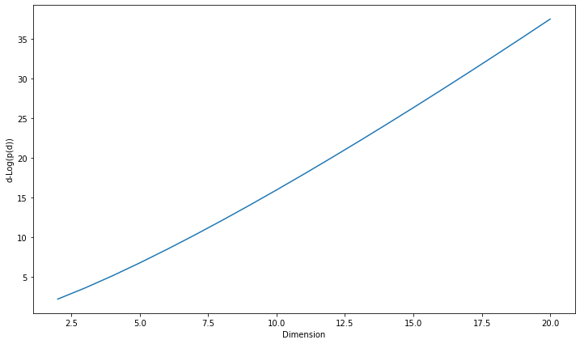

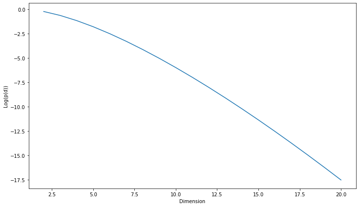

```python
import random
import statistics as stat
import matplotlib.pyplot as plt
import numpy as np
from math import log

%matplotlib inline

def Vol1(d):
    x = d/2
    return pi ** x / gamma(x + 1)

l1 = []
for i in range(2,21):
    l1.append(Vol1(i)/2**i)

logp = [np.log(x) for x in l1]
d = np.arange(2,21)
plt.figure(figsize=(12, 7))
plt.plot(d,d-logp);
plt.xlabel("Dimension");
plt.ylabel("d-Log(p(d))");

plt.figure(figsize=(12, 7))
plt.plot(d,logp);
plt.xlabel("Dimension");
plt.ylabel("Log(p(d))");
```

Παραπάνω σχεδιάστηκαν και η γραφική παράσταση "d-logp(d)" και η "logp(d)". Παρατηρούμε ότι το σχετικό σφάλμα είναι μεγάλο για τις μεγάλες διαστάσεις. Αυτό οφείλεται στο γεγονός ότι σε μεγάλες διαστάσεις, το ποσοστό του μοναδιαίου κύβου που καταλαμβάνει η εγγεγραμμένη σε αυτόν μπάλα είναι πολύ μικρό. Αυτό έχει σαν συνέπεια τα δείγματα που πέφτουν σε αυτή να είναι ελάχιστα και κατ'επέκταση η δειγματοληψία να είναι αναξιόπιστη.

##### Ερώτημα γ

γ) Αν θέλατε να πάρετε 1000 δείγματα στη μοναδιαία μπάλα 20 διαστάσεων με τη μέθοδο της απόρριψης όπως παραπάνω, πόσα περίπου δείγματα στον κύβο θα έπρεπε να φτιάξετε? Κάντε μια εκτίμηση του χρόνου που θα χρειαζόταν αυτό στον υπολογιστή σας.

*Λύση*

Η πιθανότητα να πέσει ένα τυχαίο σημείο μέσα στην μπαλα 20 διαστάσεων είναι $\frac{\omega(20)}{2^{20}} = \frac{\frac{\pi^{10}}{\Gamma(11)}}{2^{20}} = \frac{\pi^{10}}{2^{20}\cdot \Gamma(11)}= \frac{1}{4\cdot 10^{7}}$. Άρα για ένα μόνο δείγμα επιτυχίας χρειάζονται $40.000.000$ προσπάθειες

## Παραδοτέο 2

α) Κατασκευάστε ένα scatter plot στο οποίο θα φαίνονται τα 1000 δείγματα που πήρατε απο τον δίσκο $D_2$ με τον παραπάνω αλγόριθμο MCMC. Στη συνέχεια κάντε το ίδιο για delta = 0.01 και για delta = 20. Εξηγήστε σε ένα κελί κειμένου γιατί το αποτέλεσμα 'χαλάει' όταν το delta είναι "πολύ μικρό" ή "πολύ μεγάλο"?

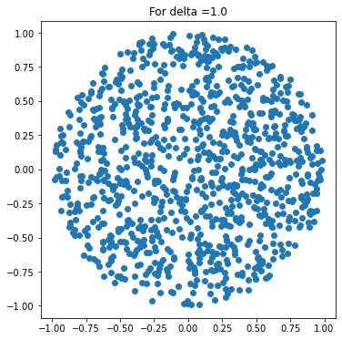

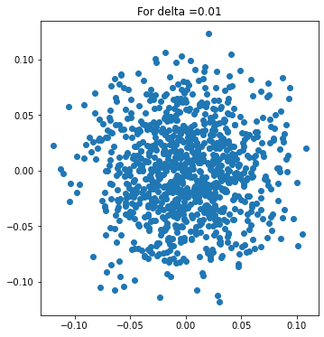

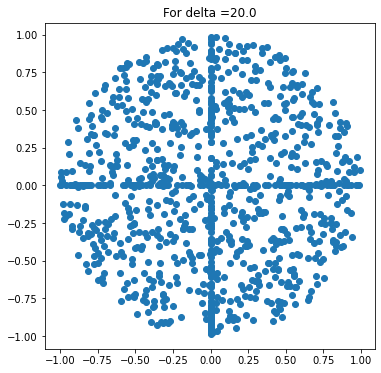

```python
import matplotlib.pyplot as plt
import random as r

for delta in[1.0 ,0.01,20.0]:
    N = 100 # number of steps to approach equilibrium
    samples = 1000
    point_x = []
    point_y = []

    for _ in range(samples):
        x = [0,0]  ## start at the centre of th disc. This variable will keep the position of the chain
        R_sq = 0.0  ## this variable keeps the squared distance from 0. It saves some computations to keep it

        for _ in range(N):
            k = r.choice([0,1])  ## choose a jump direction at random
            z = r.uniform(-delta,delta) ## choose a jump size uniformly in (-delta,delta)
            x_prop_k = x[k] + z   ## propose a jump by z in the direction k
            R_sqprop = R_sq - x[k]**2+ x_prop_k**2 ## compute the squared distance from 0 after the proposed jump
            if R_sqprop < 1.0:
                R_sq = R_sqprop
                x[k]= x_prop_k   ## if the proposed jump leads to a point in the disc, then jump

        point_x.append(x[0])
        point_y.append(x[1])

    plt.gca().set_aspect('equal', adjustable='box')
    plt.title('For delta ={}'.format(delta))
    plt.rcParams['figure.figsize'] = [6,6];
    plt.scatter(point_x,point_y);
    plt.show();
```

Παραπάνω βλέπουμε τα 3 διαγράμματα για delta=1 , delta =0.01 και delta =20 αντίστοιχα.Στην περίπτωση που delta =0.01 τα δείγματα δεν "προλαβαίνουν" να απομακρινθούν σε 100 βηματα αρκεά από το κέντρο, αφού όπως βλέπουμε ελάχιστα ξεπερνούν την απόσταση του 0.1 από το (0,0). Αντιθέτως, στην δεύτερη περίπτωση οι κινήσεις πολλών δειγμάτων απορρίπτονται με αποτέλεσμα τα δείγματα αυτά να μην φεύγουν από τους άξονες x ή y και να συγκεντρώνονται σε αυτούς οπως βλέπουμε.

##### Ερώτημα β

Γράψτε μια ρουτίνα που θα τυπώνει για διαστάσεις $d=2,3,...,100$ τον εκτιμόμενο με MCMC όγκo της μοναδιαίας μπάλας σε $d$ διαστάσεις, την πραγματική τιμή του και το σχετικό σφάλμα της εκτίμησης. Μπορείτε να ξεκινήσετε από την προφανή σχέση $|D_1|=2$ και να δουλέψετε επαγωγικά για να υπολογίσετε τα ω(2), ω(3),... Στο jupyter notebook που θα παραδώσετε τρέξτε τη ρουτίνα σας ώστε να φαίνονται τα αποτελέσματα.

*Λύση*

Ξέρωντας ότι είναι $|D_1| = 2$, οπότε μέσω της MCMC δειγματοληψίας εκτιμούμε τον λόγο $\frac{|D_{d+1}|}{|C_{d+1}|}$= $\frac{|D_{d+1}|}{2|D_d|}$ που είναι ο λόγος των σημείων του κυλίνδρου σε d+1 διαστάσεις που πέφτουν μέσα στην d+1-διάστατη σφαίρα. Έτσι εκτιμούμε το $|D_{d+1}|$ ενώ ξέρουμε το $|D_d|$. Ο κώδικας της άσκησης είναι ο εξής:

```python
import matplotlib.pyplot as plt
import random as r
import numpy as np


delta = 1
N = 100
lastd = 2
samples =10000
for d in range(1,30):
    samples_inside_D = 0

    for _ in range(samples):
        x=[0]*d
        R_sq = 0

        for _ in range(N):
            k = r.choice(np.arange(d))
            z = r.uniform(-delta,delta)
            x_prop_k = x[k] +z
            R_sqprop = R_sq - x[k]**2 + x_prop_k**2
            if R_sqprop < 1.0:
                R_sq = R_sqprop
                x[k]= x_prop_k

        x_dplus1 = r.uniform(-1,1)
        R_sq += x_dplus1**2

        if R_sq<1:
            samples_inside_D += 1


    D=2*lastd*(samples_inside_D/samples)
    lastd=D
    error= abs(Vol1(d+1)-D)/Vol1(d+1)
    print("The Monte Carlo estimate of ω(", d+1 ,") is:\t%.5f " % D)
    print("The actual value of ω(", d+1 ,") is:\t\t%.5f " % Vol1(d+1))
    print("The relative error is:\t\t\t%.5f" % error)
    print("\n")
```

```
The Monte Carlo estimate of ω( 2 ) is:	3.14840
The actual value of ω( 2 ) is:		3.14159
The relative error is:			0.00217


The Monte Carlo estimate of ω( 3 ) is:	4.20374
The actual value of ω( 3 ) is:		4.18879
The relative error is:			0.00357


The Monte Carlo estimate of ω( 4 ) is:	4.90913
The actual value of ω( 4 ) is:		4.93480
The relative error is:			0.00520


The Monte Carlo estimate of ω( 5 ) is:	5.22626
The actual value of ω( 5 ) is:		5.26379
The relative error is:			0.00713


The Monte Carlo estimate of ω( 6 ) is:	5.25135
The actual value of ω( 6 ) is:		5.16771
The relative error is:			0.01618


The Monte Carlo estimate of ω( 7 ) is:	4.81444
The actual value of ω( 7 ) is:		4.72477
The relative error is:			0.01898


The Monte Carlo estimate of ω( 8 ) is:	4.12501
The actual value of ω( 8 ) is:		4.05871
The relative error is:			0.01633


The Monte Carlo estimate of ω( 9 ) is:	3.41963
The actual value of ω( 9 ) is:		3.29851
The relative error is:			0.03672


```

[output cut: 88 more lines]

```


The Monte Carlo estimate of ω( 28 ) is:	0.00008
The actual value of ω( 28 ) is:		0.00010
The relative error is:			0.23792


The Monte Carlo estimate of ω( 29 ) is:	0.00003
The actual value of ω( 29 ) is:		0.00005
The relative error is:			0.28263


The Monte Carlo estimate of ω( 30 ) is:	0.00002
The actual value of ω( 30 ) is:		0.00002
The relative error is:			0.29693
```